```python
%matplotlib inline

import numpy as np
from matplotlib import pyplot as plt

from sklearn import gaussian_process
from sklearn.gaussian_process import kernels

import pickle
from urllib.request import urlopen
```

# Gaussian processes in scikit-learn

## Exercise 5.1: GP posterior

Repeat exercise 4.2 using `GaussianProcessRegressor` from `sklearn.gaussian_process`, only plotting the credibility regions based on the posterior predictive variance (not drawing samples).

Some useful hints:

- As all supervised machine learning methods in `sklearn`, you first have to construct an object from the model class (in this case `GaussianProcessRegressor`), and thereafter train it on data by using its member function `fit()`. To obtain predictions, use the member function `predict()`. To the latter, you will either have to pass `return_std=True` or `return_cov=True` in order to obtain information about the posterior predictive variance.
- When you construct the model, you have to define a kernel. The kernels are available in `sklearn.gaussian_process.kernel`, where the squared exponential/RBF kernel is available as `RBF`.
- The function `fit()` automatically optimizes the hyperparameters. To turn that feature off, you have to pass the argument `optimizer=None` to `GaussianProcessRegressor`.
- To include the measurement noise, you can formulate it as part of the kernel by using the kernel `WhiteKernel`.

We start by defining the observations from exercise 4.2:

```python
x = np.array([-4, -3, -1, 0, 2])
y = np.array([-2, 0, 1, 2, -1])
```

We define the test inputs as in exercise 4.2:

```python
xs = np.linspace(-5, 5, 101)
```

We define an RBF kernel with lengthscale $\ell^2 = 2$. Note that `RBF` uses $\sigma_f^2 = 1$, if you want to scale the kernel you would have to multiply it with a `ConstantKernel`.

```python
l = np.sqrt(2)
kernel = kernels.RBF(length_scale=l)
```

We construct a Gaussian process with this RBF kernel. We specify `optimizer=None` to avoid any hyperparameter tuning and `random_state` to ensure that the results are reproducible. Note that `GaussianProcessRegressor` always uses a Gaussian process with zero mean.

```python
gp = gaussian_process.GaussianProcessRegressor(
    kernel=kernel, optimizer=None, random_state=100
)
```

We update the Gaussian process regression model by fitting it to the observations, i.e., we compute the posterior Gaussian process. `fit()` expects a matrix of observations $\mathbf{x}$ and therefore we reshape `x`.

```python
gp.fit(x[:, None], y)
```

```
GaussianProcessRegressor(kernel=RBF(length_scale=1.41), optimizer=None,
                         random_state=100)
```

We compute the mean and the standard deviation of the normally distributed function values for the test inputs.

```python
mu_post, std_post = gp.predict(xs[:, None], return_std=True)
```

We plot the data and the posterior distribution for the test inputs.

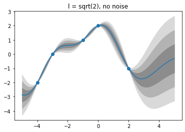

```python
plt.plot(xs, mu_post)
for i in [3, 2, 1]:
    # plot credibility regions (1, 2, and 3 standard deviations)
    plt.fill_between(
        xs, mu_post + i*std_post, mu_post - i*std_post,
        color=str(0.4 + 0.15*i), # '0' => black, '1' => white
    )
plt.scatter(x, y)
plt.title("l = sqrt(2), no noise")
plt.show()
```

We can add Gaussian measurement noise with variance $\sigma^2 = 0.1$ by constructing the kernel as a sum of an `RBF` kernel and a `WhiteKernel`.

```python
l = np.sqrt(2)
s2 = 0.1
kernel = kernels.RBF(length_scale=l) + kernels.WhiteKernel(noise_level=s2)
```

We perform the same analysis again:

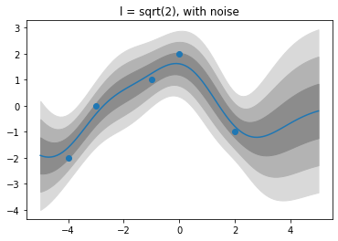

```python
# construct Gaussian process (without hyperparameter tuning)
gp = gaussian_process.GaussianProcessRegressor(
    kernel=kernel, optimizer=None, random_state=100
)

# fit model to observations
gp.fit(x[:, None], y)

# posterior mean and standard deviation of function values for test inputs
mu_post, std_post = gp.predict(xs[:, None], return_std=True)

# plot data, posterior mean and credibility regions
plt.plot(xs, mu_post)
for i in [3, 2, 1]:
    # plot credibility regions (1, 2, and 3 standard deviations)
    plt.fill_between(
        xs, mu_post + i*std_post, mu_post - i*std_post,
        color=str(0.4 + 0.15*i), # '0' => black, '1' => white
    )
plt.scatter(x, y)
plt.title("l = sqrt(2), with noise")
plt.show()
```

We repeat the study with length scale $\ell = 1/2$.

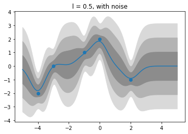

```python
# construct kernel
l = 1/2
s2 = 0.1
kernel = kernels.RBF(length_scale=l) + kernels.WhiteKernel(noise_level=s2)

# construct GP regression model (without hyperparameter tuning)
gp = gaussian_process.GaussianProcessRegressor(
    kernel=kernel, optimizer=None, random_state=100
)

# fit model to observations
gp.fit(x[:, None], y)

# posterior mean and standard deviation of function values for test inputs
mu_post, std_post = gp.predict(xs[:, None], return_std=True)

# plot data, posterior mean and credibility regions
plt.plot(xs, mu_post)
for i in [3, 2, 1]:
    # plot credibility regions (1, 2, and 3 standard deviations)
    plt.fill_between(
        xs, mu_post + i*std_post, mu_post - i*std_post,
        color=str(0.4 + 0.15*i), # '0' => black, '1' => white
    )
plt.scatter(x, y)
plt.title("l = 0.5, with noise")
plt.show()
```

## Exercise 5.2: Learning hyperparameters

Until now, we have made GP regression using predefined hyperparameters, such as the lengthscale $\ell$ and noise variance $\sigma^2$. In this exercise, we will estimate $\ell$ and $\sigma^2$ from the data by maximizing the marginal likelihood (cf. exercise 4.4 and 4.5). That is done automatically by the `fit()` function in scikit-learn. Use, as before, the RBF kernel and measurement noise together, this time with the data \begin{equation*} \mathbf{x} = \begin{bmatrix}-5 &-3 &0 &0.1 &1 &4.9 &5\end{bmatrix}^\mathsf{T} \,\text{ and }\, \mathbf{y} = \begin{bmatrix}0 &-0.5 &1 &0.7 &0 &1 &0.7\end{bmatrix}^\mathsf{T}. \end{equation*}

### (a)

You still have to provide an initial value of the hyperparameters. Try $\ell = 1$ and $\sigma^2 = 0.1$. What hyperparameters do you get when optimizing? Plot the corresponding mean and credibility regions.

We define the data

```python
x = np.array([-5, -3, 0, 0.1, 1, 4.9, 5])
y = np.array([0, -0.5, 1, 0.7, 0, 1, 0.7])
```

and the GP regression model with an RBF kernel with measurement noise with initial hyperparameters $\ell = 1$ and $\sigma^2 = 0.1$:

```python
kernel = kernels.RBF(length_scale=1) + kernels.WhiteKernel(noise_level=0.1)
gp = gaussian_process.GaussianProcessRegressor(
    kernel=kernel, random_state=100
)
```

When we fit the GP regression model to the observations with `fit()`, the hyperparameters $\ell$ and $\sigma^2$ are optimized automatically. We see that the optimized kernel `gp.kernel_` of the model has a length scale $\ell = 1$ and a noise variance $\sigma^2 = 0.032$.

```python
gp.fit(x[:, None], y)
print(gp.kernel_)
```

```
RBF(length_scale=1) + WhiteKernel(noise_level=0.032)
```

We plot the posterior mean and credibility regions of the function values for 101 equally spaced test inputs between -6 and 6.

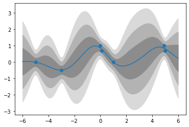

```python
# posterior mean and standard deviation of function values for test inputs
xs = np.linspace(-6, 6, 101)
mu_post, std_post = gp.predict(xs[:, None], return_std=True)

# plot data, posterior mean and credibility regions
plt.plot(xs, mu_post)
for i in [3, 2, 1]:
    # plot credibility regions (1, 2, and 3 standard deviations)
    plt.fill_between(
        xs, mu_post + i*std_post, mu_post - i*std_post,
        color=str(0.4 + 0.15*i), # '0' => black, '1' => white
    )
plt.scatter(x, y)
plt.show()
```

### (b)

Try instead to initialize with $\ell = 10$ and $\sigma^2 = 1$. What do you get now?

We repeat the analysis in part (a) but initialize the kernel with hyperparameters $\ell = 10$ and $\sigma^2 = 1$.

```
RBF(length_scale=10.7) + WhiteKernel(noise_level=0.222)
```

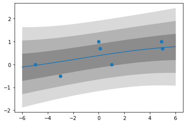

```python
# initialize kernel and GP regression model
kernel = kernels.RBF(length_scale=10) + kernels.WhiteKernel(noise_level=1)
gp = gaussian_process.GaussianProcessRegressor(
    kernel=kernel, random_state=100
)

# fit model to observations and display optimized hyperparameters
gp.fit(x[:, None], y)
print(gp.kernel_)

# posterior mean and standard deviation of function values for test inputs
xs = np.linspace(-6, 6, 101)
mu_post, std_post = gp.predict(xs[:, None], return_std=True)

# plot data, posterior mean and credibility regions
plt.plot(xs, mu_post)
for i in [3, 2, 1]:
    # plot credibility regions (1, 2, and 3 standard deviations)
    plt.fill_between(
        xs, mu_post + i*std_post, mu_post - i*std_post,
        color=str(0.4 + 0.15*i), # '0' => black, '1' => white
    )
plt.scatter(x, y)
plt.show()
```

### (c)

Try to explain what happens by making a grid over different hyperparameter values, and inspect the marginal likelihood for each point in that grid. The `GaussianProcessRegressor` class has a member function `log_marginal_likelihood()` which you may use. (Do not forget to turn off the hyperparameter optimization!)

We implement a function that computes the marginal likelihood for a given lengthscale $\ell$ and noise variance $\sigma^2$.

```python
def marginal_likelihood(l, s2):
    # construct kernel with measurement noise
    kernel = kernels.RBF(length_scale=l) + kernels.WhiteKernel(noise_level=s2)

    # construct GP regression model (without hyperparameter tuning!)
    gp = gaussian_process.GaussianProcessRegressor(kernel=kernel, optimizer=None)

    # compute posterior GP and evaluate marginal likelihood
    gp.fit(x[:, None], y)
    return np.exp(gp.log_marginal_likelihood())
```

Using this function we compute and plot the marginal likelihood for a logarithmically spaced grid of lengthscales $\ell$ between 0.1 and 100 and noise variances $\sigma^2$ between 0.01 and 1.

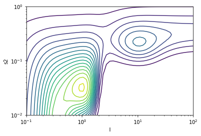

```python
# compute marginal likelihood for a grid of lengthscales and noise variances
ls = np.logspace(-1, 2, 51)
s2s = np.logspace(-2, 0, 51)
marginal_likelihoods = [[marginal_likelihood(l, s2) for l in ls] for s2 in s2s]

# plot marginal likelihoods
plt.contour(ls, s2s, marginal_likelihoods, levels=20)
plt.xscale("log")
plt.yscale("log")
plt.xlabel("l")
plt.ylabel("s2")
plt.show()
```

## Exercise 5.3: Modeling CO₂ levels

The amount of carbon dioxide in the atmosphere has been measured continuously at the Mauna Loa observatory, Hawaii. In this problem, you should use a Gaussian process to model the data from 1958 to 2003, and see how well that model can be used for predicting the data from 2004-2019. They present their latest data at [their homepage](https://www.esrl.noaa.gov/gmd/ccgg/trends/), but for your convenience you can use the data in the format available [here](https://github.com/gpschool/labs/raw/2019/.resources/mauna_loa). You can load the data with the following code snippet:

```python
# download data
data = pickle.load(
    urlopen("https://github.com/gpschool/labs/raw/2019/.resources/mauna_loa")
)

# extract observations and test data
x = data['X'].flatten()
y = data['Y'].flatten()
xtest = data['Xtest'].flatten()
ytest = data['Ytest'].flatten()
```

Here, `x` and `y` contain your training data.

Start exploring some simple kernels, and thereafter you may have a look at page 118-122 of the book [Gaussian processes for machine learning](http://www.gaussianprocess.org/gpml/chapters/RW5.pdf) for some inspiration on how to design a more bespoke kernel for this problem.

We create a GP regression model with an RBF kernel and measurement noise and fit it to the data, including hyperparameter tuning.

```python
kernel = 100 * kernels.RBF(length_scale=100) + kernels.WhiteKernel(noise_level=1)
gp = gaussian_process.GaussianProcessRegressor(kernel=kernel)
gp.fit(x[:, None], y)
print(gp.kernel_)
```

```
316**2 * RBF(length_scale=52.4) + WhiteKernel(noise_level=4.51)
```

We plot posterior mean and credibility regions for years 1957 to 2040.

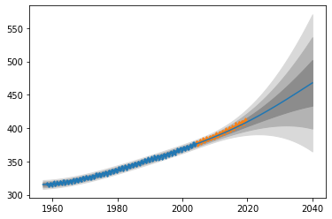

```python
# posterior mean and standard deviation of function values for test inputs
xs = np.linspace(1957, 2040, 200)
mu_post, std_post = gp.predict(xs[:, None], return_std=True)

# plot data, posterior mean and credibility regions
plt.plot(xs, mu_post)
for i in [3, 2, 1]:
    # plot credibility regions (1, 2, and 3 standard deviations)
    plt.fill_between(
        xs, mu_post + i*std_post, mu_post - i*std_post,
        color=str(0.4 + 0.15*i), # '0' => black, '1' => white
    )
plt.scatter(x, y, s=1)
plt.scatter(xtest, ytest, s=1)
plt.show()
```

More elaborate models are implemented e.g. [here](https://scikit-learn.org/stable/auto_examples/gaussian_process/plot_gpr_co2.html) and in exercise 7 [here](https://nbviewer.jupyter.org/github/gpschool/labs/blob/2019/2019/.answers/lab_1.ipynb) (however using another GP package).